# Transformed Variables Regression Problem Set

# 1 Boiling Point Water

In the 1800s, [Joseph Hooker](https://en.wikipedia.org/wiki/Joseph_Dalton_Hooker) collected data on the boiling point of water at various pressures in the Himilayas. He did this so he could approximate the altitude (via the air pressure) by boiling water instead of carrying fragile barometers in the mountains.

He used this data (originally taken from [here](http://www.math.mcgill.ca/~dstephens/OldCourses/204-2007/Handouts/Math204-LinearRegressionExamples.pdf) ).

## 1.1 Initial Model

1. Plot the data with pressure as a function of temperature. Does linear regression seem to be appropriate?

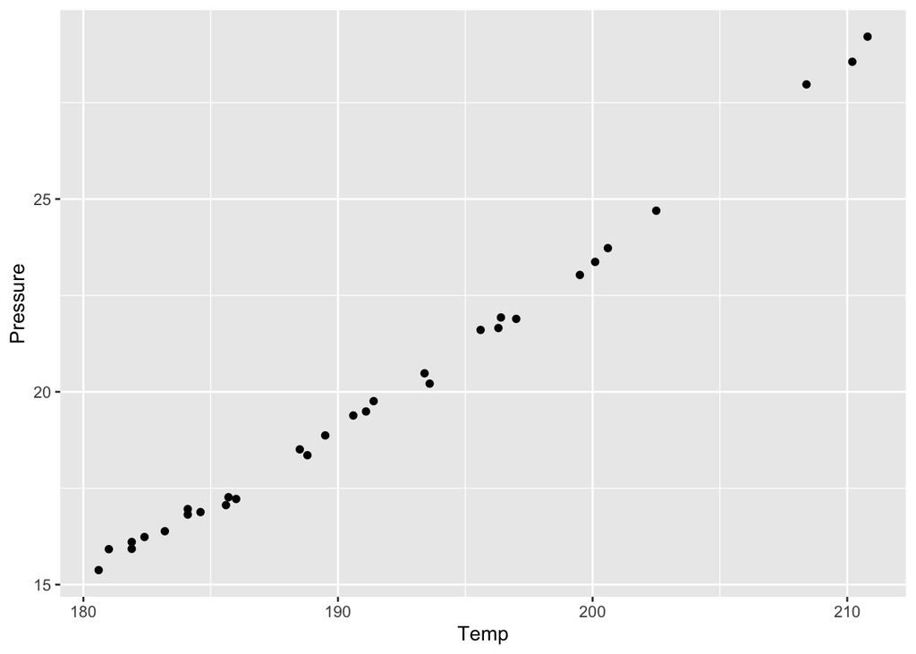

```r
library(tidyverse)

tp <- read.csv('temp_pressure.csv')

ggplot(tp) + geom_point(aes(x = Temp, y = Pressure))
```

```r
# This appears to be linear.
```

2. Conduct a simple linear regression. Check your assumptions. Do you meet your assumptions?

```r
# model in the standard way
simple.model <- lm(Pressure ~ Temp, tp)

# look at the results
summary(simple.model)
```

```
##
## Call:
## lm(formula = Pressure ~ Temp, data = tp)
##
## Residuals:
##      Min       1Q   Median       3Q      Max
## -0.61383 -0.24968 -0.09921  0.26365  0.81232
##
## Coefficients:
##               Estimate Std. Error t value Pr(>|t|)
## (Intercept) -64.412751   1.429165  -45.07   <2e-16 ***
## Temp          0.440282   0.007444   59.14   <2e-16 ***
## ---
## Signif. codes:  0 '***' 0.001 '**' 0.01 '*' 0.05 '.' 0.1 ' ' 1
##
## Residual standard error: 0.3563 on 29 degrees of freedom
## Multiple R-squared:  0.9918, Adjusted R-squared:  0.9915
## F-statistic:  3498 on 1 and 29 DF,  p-value: < 2.2e-16
```

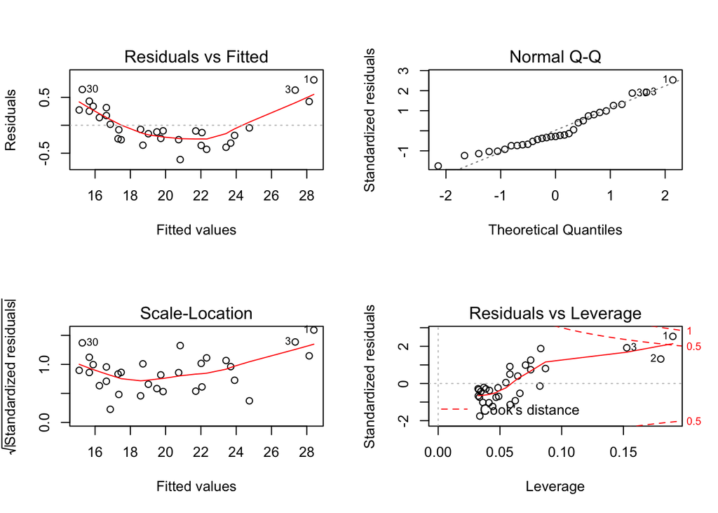

```r
# We appear to have a significant relationship.

par(mfrow = c(2,2))
plot(simple.model)
```

```r
# We can clearly see that we don't have constant variance
# We effectively have all positive residuals at low and high pressures and
# all negative residuals at medium pressures

# we also have a few apparent outliers
```

## 1.2 Transformed Model

1. Try modeling the data with the following transformations:
- Square Root of Temperature
- Natural Log of Temperature
- Inverse of Temperature
- Log10 of Temperature and Log10 of Pressure

Are any of these appropriate? If so, which one?

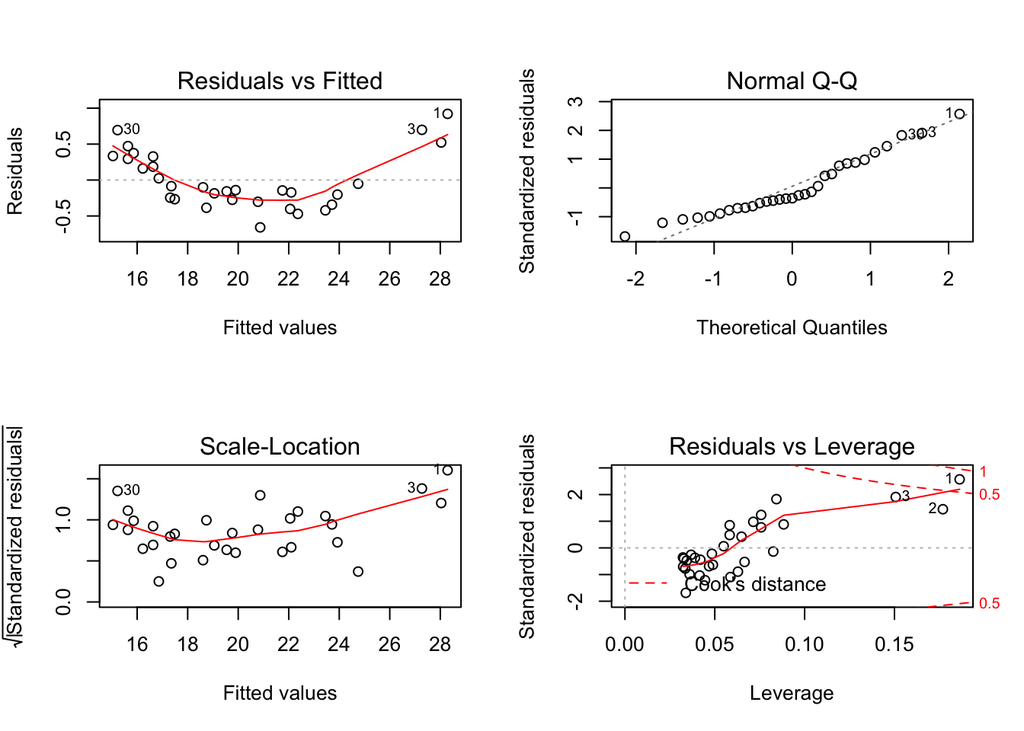

```r
# Square Root of Temperature
sqrt.model <- lm(Pressure ~ sqrt(Temp), tp)
par(mfrow = c(2,2))
plot(sqrt.model)
```

```r
# This suffers the same problem
```

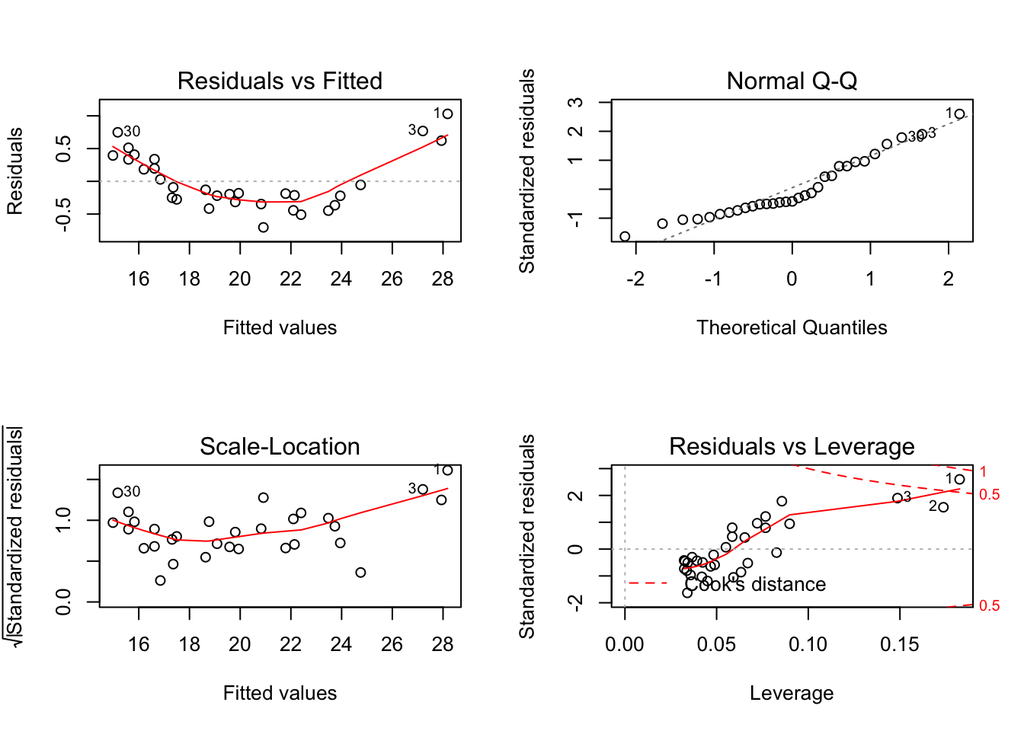

```r
# Natural Log of Temperature
ln.model <- lm(Pressure ~ log(Temp), tp)
par(mfrow = c(2,2))
plot(ln.model)
```

```r
# This suffers the same problem
```

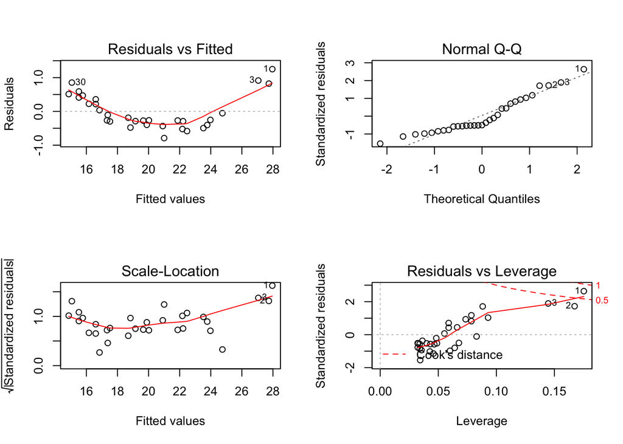

```r
# Inverse of Temperature
inv.model <- lm(Pressure ~ I(1/Temp), tp)
par(mfrow = c(2,2))
plot(inv.model)
```

```r
# This suffers the same problem
```

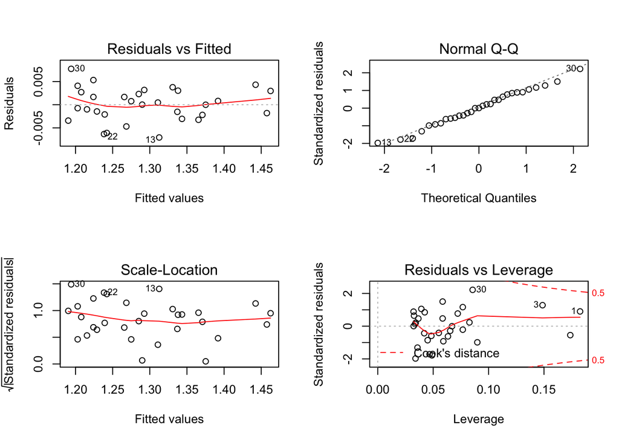

```r
# Log Log of Temperature
loglog.model <- lm(log10(Pressure) ~ log10(Temp), tp)
par(mfrow = c(2,2))
plot(loglog.model)
```

```r
# This appears to be a pretty good model, let's check further

# Normal
shapiro.test(resid(loglog.model))
```

```
##
##  Shapiro-Wilk normality test
##
## data:  resid(loglog.model)
## W = 0.98603, p-value = 0.9486
```

```r
# We fail to reject that we are not normal - we meet that assumption

# Homoscedasticity
car::ncvTest(loglog.model)
```

```
## Non-constant Variance Score Test
## Variance formula: ~ fitted.values
## Chisquare = 1.287752, Df = 1, p = 0.25646
```

```r
# We fail to reject that we have constant variance
```

2. Pick the best model of the above options and:

2a. Write the mathematical equation:

```r
summary(loglog.model)
```

```
##
## Call:
## lm(formula = log10(Pressure) ~ log10(Temp), data = tp)
##
## Residuals:
##        Min         1Q     Median         3Q        Max
## -0.0070749 -0.0021493  0.0000161  0.0028415  0.0077427
##
## Coefficients:
##             Estimate Std. Error t value Pr(>|t|)
## (Intercept) -7.96044    0.07776  -102.4   <2e-16 ***
## log10(Temp)  4.05488    0.03407   119.0   <2e-16 ***
## ---
## Signif. codes:  0 '***' 0.001 '**' 0.01 '*' 0.05 '.' 0.1 ' ' 1
##
## Residual standard error: 0.003645 on 29 degrees of freedom
## Multiple R-squared:  0.998,  Adjusted R-squared:  0.9979
## F-statistic: 1.416e+04 on 1 and 29 DF,  p-value: < 2.2e-16
```

$$log_{10}(P) = -7.96 + 4.05 log_{10}(T)$$

This is equivalent to:

$$P = 10^{-7.96} \cdot T^{4.05}$$

2b. Plot your results in the transformed and original units. Compare this with your original, simple model (in original units only).

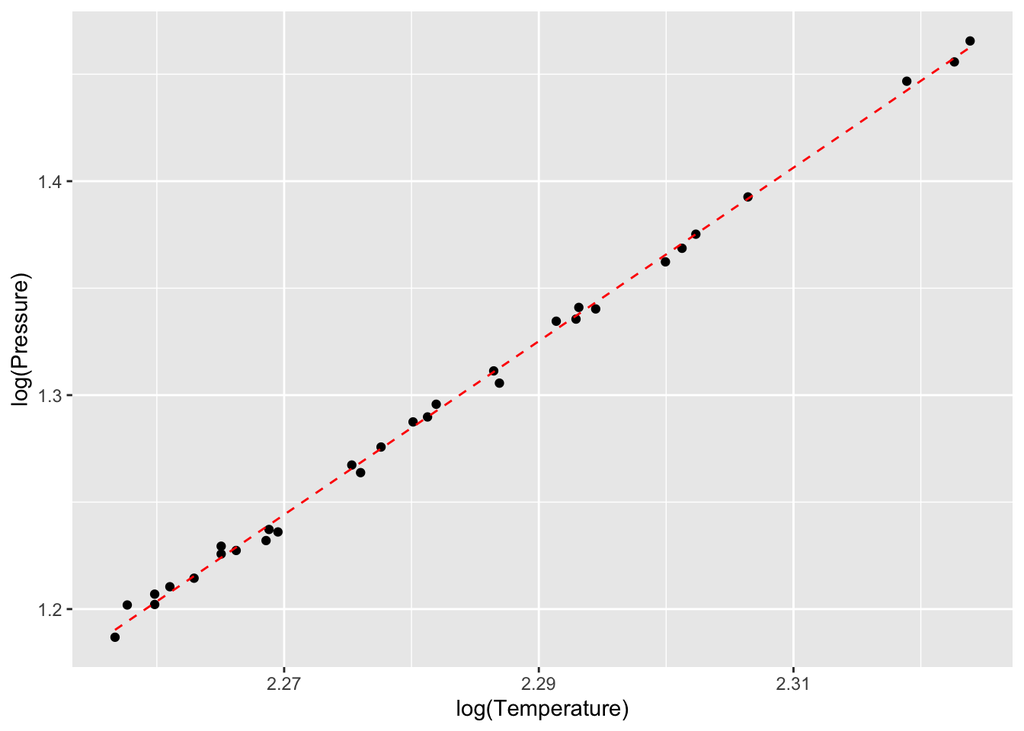

```r
#Transformed Units
tp <- tp %>% mutate(log.temp = log10(Temp), log.pres = log10(Pressure))
# get a sequence to make the model line
loglog.line <- seq(min(tp$log.temp), max(tp$log.temp), by = .001)

ggplot() +
  # plot the observations
  geom_point(data = tp, aes(x = log.temp, y = log.pres)) +
  # Plot a line using the sequence and linear formula from the model
  geom_line(aes(x = loglog.line,
                y = loglog.model$coefficients[1] +
                  loglog.model$coefficients[2]*loglog.line),
            lty = 2, color = 'red') +
  xlab('log(Temperature)') + ylab('log(Pressure)')
```

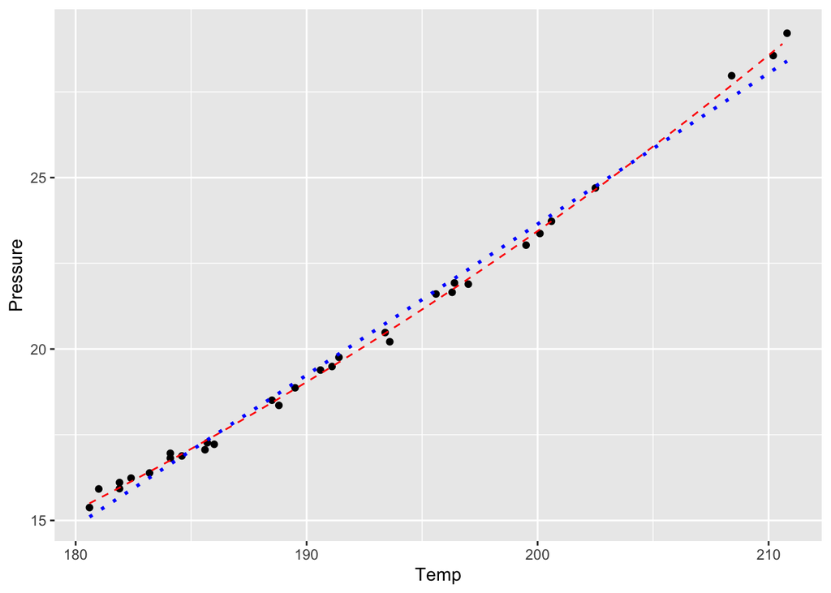

```r
# Original Units
# Build a line with the transformed equation
original.line <- seq(min(tp$Temp), max(tp$Temp), by = 1)
original.pressure <- (10^loglog.model$coefficients[1]) * (original.line^loglog.model$coefficients[2])

# Plot the results in the original form
ggplot() +
  geom_point(aes(x = Temp, y = Pressure), data = tp) +
  geom_line(aes(x = original.line, y = original.pressure), lty = 2, color = 'red') +
  stat_smooth(data = tp, method = 'lm', se = F, aes(x = Temp, y = Pressure), color = 'blue', lty = 3)
```

```r
# We see this is a much better fit.  The red line (transfomred model) is much more consistent
# the simple model misses the subtle curvature
```